Time Series Analysis[TSA] isa a method of analyzing the data points collected over time to identify pattterns,trends and seasonal variations its is used to forcast the future values based on the historical data

# TSA

```python
import pandas as pd
import matplotlib.pyplot as plt
import seaborn as sns
import numpy as np
from statsmodels.tsa.stattools import adfuller
from statsmodels.tsa.seasonal import seasonal_decompose
from statsmodels.tsa.arima.model import ARIMA
```

LOADING AND VIEWING DATA

```python
df=pd.read_csv(r"C:\Users\DELL\Downloads\DailyDelhiClimateTrain.csv")
```

```python
df.head()
```

|  | date | meantemp | humidity | wind_speed | meanpressure |
| --- | --- | --- | --- | --- | --- |
| 0 | 2013-01-01 | 10.000000 | 84.500000 | 0.000000 | 1015.666667 |
| 1 | 2013-01-02 | 7.400000 | 92.000000 | 2.980000 | 1017.800000 |
| 2 | 2013-01-03 | 7.166667 | 87.000000 | 4.633333 | 1018.666667 |
| 3 | 2013-01-04 | 8.666667 | 71.333333 | 1.233333 | 1017.166667 |
| 4 | 2013-01-05 | 6.000000 | 86.833333 | 3.700000 | 1016.500000 |

```python
df.info()
```

```
<class 'pandas.core.frame.DataFrame'>
RangeIndex: 1462 entries, 0 to 1461
Data columns (total 5 columns):
 #   Column        Non-Null Count  Dtype
---  ------        --------------  -----
 0   date          1462 non-null   object
 1   meantemp      1462 non-null   float64
 2   humidity      1462 non-null   float64
 3   wind_speed    1462 non-null   float64
 4   meanpressure  1462 non-null   float64
dtypes: float64(4), object(1)
memory usage: 57.2+ KB
```

```python
print(df[df['date'].isna()])
```

```
Empty DataFrame
Columns: [date, meantemp, humidity, wind_speed, meanpressure]
Index: []
```

```python
df['date']=pd.to_datetime(df['date'],errors='coerce')
df.info()
```

```
<class 'pandas.core.frame.DataFrame'>
RangeIndex: 1462 entries, 0 to 1461
Data columns (total 5 columns):
 #   Column        Non-Null Count  Dtype
---  ------        --------------  -----
 0   date          1462 non-null   datetime64[ns]
 1   meantemp      1462 non-null   float64
 2   humidity      1462 non-null   float64
 3   wind_speed    1462 non-null   float64
 4   meanpressure  1462 non-null   float64
dtypes: datetime64[ns](1), float64(4)
memory usage: 57.2 KB
```

```python
df.set_index('date',inplace=True)
df.head()
```

| date | meantemp | humidity | wind_speed | meanpressure |
| --- | --- | --- | --- | --- |
| 2013-01-01 | 10.000000 | 84.500000 | 0.000000 | 1015.666667 |
| 2013-01-02 | 7.400000 | 92.000000 | 2.980000 | 1017.800000 |
| 2013-01-03 | 7.166667 | 87.000000 | 4.633333 | 1018.666667 |
| 2013-01-04 | 8.666667 | 71.333333 | 1.233333 | 1017.166667 |
| 2013-01-05 | 6.000000 | 86.833333 | 3.700000 | 1016.500000 |

VISULIZE

```python
df.describe()
```

|  | meantemp | humidity | wind_speed | meanpressure |
| --- | --- | --- | --- | --- |
| count | 1462.000000 | 1462.000000 | 1462.000000 | 1462.000000 |
| mean | 25.495521 | 60.771702 | 6.802209 | 1011.104548 |
| std | 7.348103 | 16.769652 | 4.561602 | 180.231668 |
| min | 6.000000 | 13.428571 | 0.000000 | -3.041667 |
| 25% | 18.857143 | 50.375000 | 3.475000 | 1001.580357 |
| 50% | 27.714286 | 62.625000 | 6.221667 | 1008.563492 |
| 75% | 31.305804 | 72.218750 | 9.238235 | 1014.944901 |
| max | 38.714286 | 100.000000 | 42.220000 | 7679.333333 |

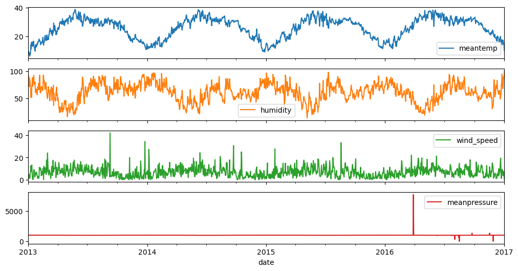

```python
df.plot(figsize=(12,6),subplots=True)
plt.show()
```

Conclusion: 1.IN this graph every year follows a trend 2. maximun Mean temp is 38 and minimum mean temp is 6 3.humidity maximun is 100 and minimum is 13 4. in wind speed spy is increases in between 2013 and 2014 5.Mean pressure,spy is constant 2013 to 2016,whereas spy is incresed in 2016 and 2017

SATIONARY

A time series is stationay if it is a statistical properties(meaan,variance,autocorelation)reamins constant over time

-HYPOTHESIS OD ADF TEST 1.NULL HYPOTHESIS:-The time series has a unit root(i.e,it is a non-satiionary) 2.ALTERNATIVE HYPOTHESIS:-The time series does not have any unit root(i.e,it is stationary)

INTERPRETING ADF TEST RESULTS: 1.if the p-value is less than 0.05,reject Ho ->The series is stationary 2.if the p-value is more than 0.05,fail to reject Ho->The series is non-stationary

```python
adfuller_result=adfuller(df['meantemp'])
```

```python
print(adfuller_result)
```

```
(-2.0210690559206728, 0.27741213723016056, 10, 1451, {'1%': -3.4348647527922824, '5%': -2.863533960720434, '10%': -2.567831568508802}, 5423.895746470953)
```

```python
if adfuller_result[1]<0.05:
    print("it is a stationary")
else:
    print("it is non-stationay")
```

```
it is non-stationay
```

Differencing to remove theb trend:if the series is non- stationay,apply differencing.

Differencing is a technique used to make a non stationay time series stationay by removing the trends or seasonality.it involves the substracting the previous observation from the present observation

temperature = [20,21,22,24,25,27,28, 27]

Difference = [nan, 1, 1, 2, 1, 2, 1, -1]

The new series fluctuates around zero -2 to 2

```python
df['meantemp_diff']=df['meantemp'].diff()
df.head()
```

| date | meantemp | humidity | wind_speed | meanpressure | meantemp_diff |
| --- | --- | --- | --- | --- | --- |
| 2013-01-01 | 10.000000 | 84.500000 | 0.000000 | 1015.666667 | NaN |
| 2013-01-02 | 7.400000 | 92.000000 | 2.980000 | 1017.800000 | -2.600000 |
| 2013-01-03 | 7.166667 | 87.000000 | 4.633333 | 1018.666667 | -0.233333 |
| 2013-01-04 | 8.666667 | 71.333333 | 1.233333 | 1017.166667 | 1.500000 |
| 2013-01-05 | 6.000000 | 86.833333 | 3.700000 | 1016.500000 | -2.666667 |

```python
adfuller_result_afterdiff=adfuller(df['meantemp_diff'].dropna())
if adfuller_result_afterdiff[1]>0.05:
    print("it is non-stationary")
else:
    print("it is stationary")
```

```
it is stationary
```

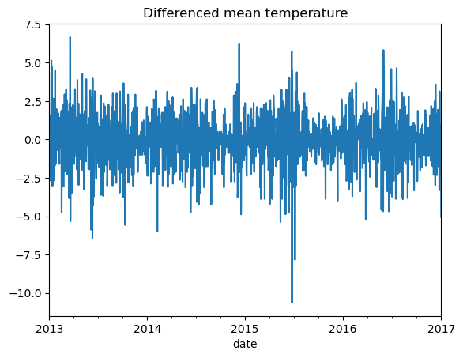

```python
df['meantemp_diff'].plot(title="Differenced mean temperature")
plt.show()
```

SEASONAL DECOMPOSITION

USE SEASONAL DECOMPOSITION TO ANALYZE THE TREND SEASONALITY AND RESIDUALS

TREND:-the long term pattern(increase or decrease overtime SEASONALITY:-The repeating patterns at fuxed intervals (example:-monthly sales spikes) RESIDUAL:-The random variations that re not explained by trend or seasonality

INTEPRETING THE OUTPUT: 1.Original series::-The raw time series data 2. Trend Component:-The genral direction of the data over time 3.Seasonal component:-The repeating patterns(example:-higher sales in december) 4.Residual component:-The remaining part after remiving trend and seasonality(example:-random noise)

```python
decomposing=seasonal_decompose(df['meantemp'],model='additive',period=365)
```

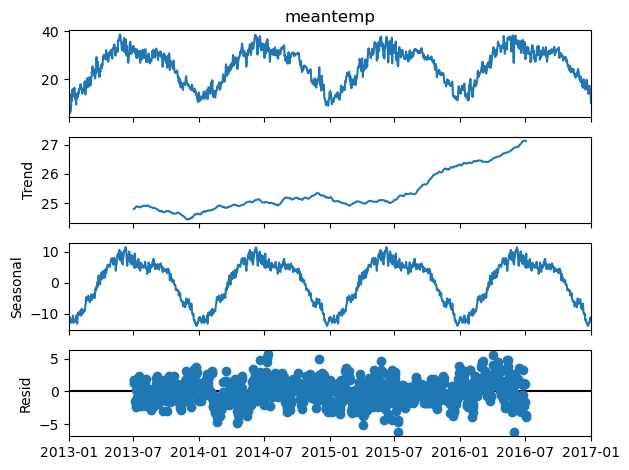

```python
decomposing.plot()
plt.show()
```

Conclusion: -There is a rapid increase in temperature i.e,it is drastically increased in between 2015 and 2016 -from 2013 to 2015 it is a slightly constant temperature -Seasonal:-it is a non stationary does not found any constant temperature graph in seasonal it is consistent temperature

SPliTTING DATA

```python
len(df)
```

```
1462
```

```python
print(len(df)*0.8)
```

```
1169.6000000000001
```

```python
train=df.iloc[0:1169]
test=df.iloc[1169:]
len(test)
```

```
293
```

CREATE AND TRAIN THE MODEL

```python
mymodel=ARIMA(train['meantemp'],order=(1,1,1))
```

[output not shown]

```python
mymodel=mymodel.fit()
```

```python
forecast=mymodel.forecast(steps=len(test))
print(forecast.head())
```

```
2016-03-15    22.826205
2016-03-16    23.085687
2016-03-17    23.234913
2016-03-18    23.320731
2016-03-19    23.370084
Freq: D, Name: predicted_mean, dtype: float64
```

```python
test['forecast']=forecast
test.head()
```

| date | meantemp | humidity | wind_speed | meanpressure | meantemp_diff | forecast |
| --- | --- | --- | --- | --- | --- | --- |
| 2016-03-15 | 24.066667 | 58.933333 | 8.646667 | 1014.866667 | 1.691667 | 22.826205 |
| 2016-03-16 | 23.937500 | 53.750000 | 10.881250 | 1012.812500 | -0.129167 | 23.085687 |
| 2016-03-17 | 26.312500 | 50.312500 | 6.843750 | 1010.437500 | 2.375000 | 23.234913 |
| 2016-03-18 | 26.187500 | 61.250000 | 6.712500 | 1009.812500 | -0.125000 | 23.320731 |
| 2016-03-19 | 26.785714 | 61.857143 | 3.578571 | 1009.214286 | 0.598214 | 23.370084 |

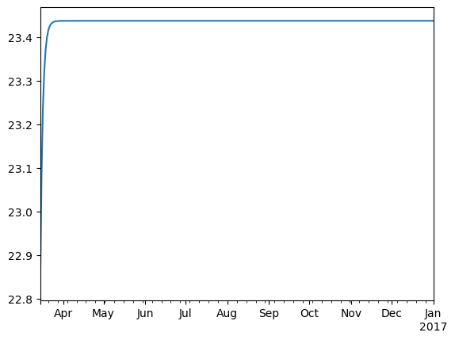

```python
forecast.plot()
plt.show()
```

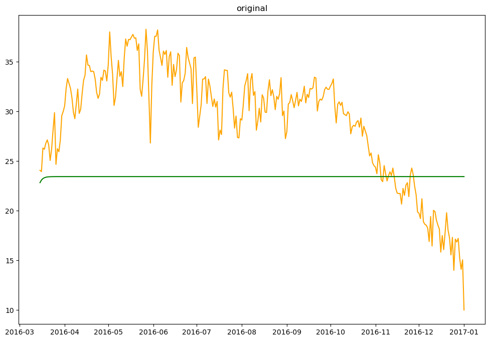

```python
plt.figure(figsize=(12,8))
plt.plot(test.index,test['meantemp'],color='orange',label="original")
plt.plot(test.index,test['forecast'],color='green',label="original")
plt.title("original")
plt.show()
```

```python
len(df)
```

```
1462
```

```python
print(len(df)*0.8)
```

```
1169.6000000000001
```

```python
train1=df.iloc[0:1169]
test1=df.iloc[1169:]
len(test)
```

```
293
```

```python
mymodel1_diff=ARIMA(train1['meantemp_diff'],order=(1,1,1))
```

[output not shown]

```python
mymodel1=mymodel1.fit()
```

```python
forecast=mymodel1.forecast(steps=len(test1))
print(forecast.head())
```

[output not shown]

```python
test1['forecast']=forecast
test1.head()
```

[output not shown]

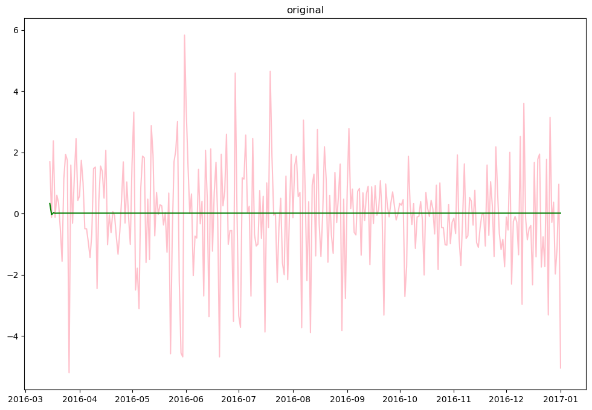

```python
plt.figure(figsize=(12,8))
plt.plot(test1.index,test1['meantemp_diff'],color='pink',label="original")
plt.plot(test1.index,test1['forecast'],color='green',label="original")
plt.title("original")
plt.show()
```